# Review of Statistical Inference

## Introduction

- This lecture reviews the concepts of statistical estimation and inference:
  - point estimation
  - interval estimation
  - hypothesis testing
- There is an interactive widget in this lecture’s slides – please see class website :)

## Point Estimation

- **point estimate** a sample statistic that estimates the value of a population parameter; this estimate is based on the sample data.
- Sample statistics estimate population parameters.
  - $\bar{x}$ estimates $\mu$
  - $s$ estimates $\sigma$
  - $\hat{p}_1 - \hat{p}_2$ estimates $\pi_1 - \pi_2$

## Interval Estimation

- **confidence interval** a *range* of plausible values for the parameter under investigation; this estimate is based on the sample data.
  - Lower bound: minimum plausible value for the parameter according to the data
  - Upper bound: maximum plausible value for the parameter according to the data
- Confidence intervals are found for population parameters.
  - CI for $\pi$
  - CI for $\mu_1-\mu_2$
  - CI for $\sigma^2$

## Interval Estimation

- **level of estimation** the expected proportion of intervals that will contain the true value of the population parameter if the population is repeatedly sampled.
- A common level of estimation is **95%**.
  - If we were to draw 100 samples from the same population, we expect 95 of the estimated confidence intervals to contain the true value of the population parameter.

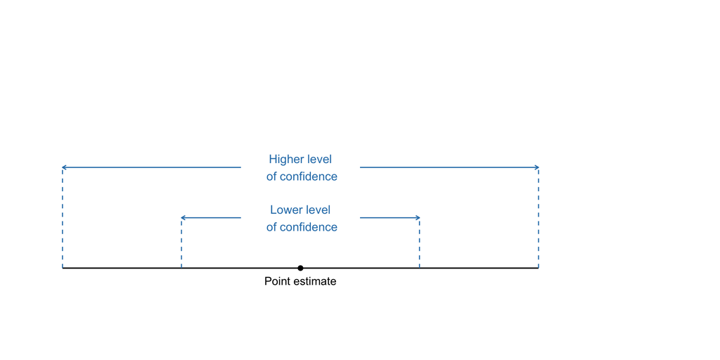

## Confidence Intervals

- Often, confidence intervals will take the form

$$\text{point estimate} \ \pm \ \text{margin of error}$$

- Lower bound = point estimate $-$ margin of error
- Upper bound = point estimate $+$ margin of error
- The margin of error is the critical value $\times$ standard error.
  - The critical value will depend on the level of confidence and the sampling distribution of the point estimate.
  - The standard error corresponds to the point estimate.

## Example 1

- The Grand Floridian claims average wait time at the Beach Pool bar is 8 minutes, but guests believe it is longer.
  - Analyst determines that the 95% CI for $\mu$ is (8.09, 11.91)
  - We are 95% confident the true average wait time at the Beach Pool bar during summer break is between 8.09 and 11.91 minutes.
- Takeaway: because the interval is larger than 8, the average wait time is likely longer than 8 minutes.

## Example 2

- Disney wonders if the nightly campfires are less popular at Port Orleans French Quarter than at Port Orleans Riverside.
  - Analyst determines that the 95% CI for $\pi_{\text{POFQ}} - \pi_{\text{POR}}$ is ($-$0.321, 0.021).
  - We are 95% confident the true difference in campfire attendance proportions (POFQ − POR) is between $-$0.321 and 0.021.
- Takeaway: because the interval contains 0, we cannot conclude that one resort’s campfire is more popular than the other.

## Hypothesis Testing

- **hypothesis testing** a statistical procedure that allows us to make inferences about population parameters based on sample data.
- General steps:
  1. Make a statement about the nature of the population.
  2. Collect evidence to test the statement.
  3. Analyze the data to determine the plausibility of the statement.

## Hypotheses

- **hypothesis** a statement regarding the population parameter.
- We will be stating two hypotheses: the null and the alternative.
  - **$H_0$: null hypothesis** a mathematical statement about the population parameter; this hypothesis is assumed *true* until evidence indicates otherwise.
  - **$H_1$: alternative hypothesis** a statement about the population parameter that contradicts the null hypothesis; this is also called the research hypothesis.
- Note! $H_0 + H_1$ should cover the real line, $\mathbb{R}$.
  - Some textbooks teach that “$=$” is *always* used in $H_0$.

## Hypotheses

- **One sample tests**
  - **Two-tailed test**
    - $H_0:$ parameter $=$ hypothesized value
    - $H_1:$ parameter $\ne$ hypothesized value
  - **Left-tailed test**
    - $H_0:$ parameter $\ge$ hypothesized value
    - $H_1:$ parameter $<$ hypothesized value
  - **Right-tailed test**
    - $H_0:$ parameter $\le$ hypothesized value
    - $H_1:$ parameter $>$ hypothesized value

## Hypotheses

- **Two sample tests**
  - **Two-tailed test**
    - $H_0:$ parameter<sub>1</sub> $-$ parameter<sub>2</sub> $=$ hypothesized difference
    - $H_1:$ parameter<sub>1</sub> $-$ parameter<sub>2</sub> $\ne$ hypothesized difference
  - **Left-tailed test**
    - $H_0:$ parameter<sub>1</sub> $-$ parameter<sub>2</sub> $\ge$ hypothesized difference
    - $H_1:$ parameter<sub>1</sub> $-$ parameter<sub>2</sub> $<$ hypothesized difference
  - **Right-tailed test**
    - $H_0:$ parameter<sub>1</sub> - parameter<sub>2</sub> $\le$ hypothesized difference
    - $H_1:$ parameter<sub>1</sub> - parameter<sub>2</sub> $>$ hypothesized difference

## Hypotheses

- Examples:
  - “Guests spend more at Disney’s Hollywood Studios than at Disney’s Animal Kingdom” $\to$ $H_1: \mu_{\text{DHS}} > \mu_\text{DAK}$.
  - “The proportion of guests who purchase Lightning Lane passes differs between annual passholders and single-day ticket holders” $\to$ $H_1: \pi_\text{AP} \ne \pi_\text{SD}$.
  - “The difference in Lightning Lane purchase rates between passholders and single-day guests less than 10 percentage points” $\to$ $H_1: \pi_\text{AP} - \pi_\text{SD} < 0.10$.
  - “The wait time for a ride is different in the morning vs. the afternoon on the same day” $\to$ $H_1: \mu_d \ne 0$, where $\mu_d = \mu_\text{am} - \mu_\text{pm}$.

## Hypotheses

- Once we have the alternative hypotheses, we know the null hypothesis is in the opposite direction.
  - “Guests spend more than $50/day at a theme park”
    - $H_0: \mu \le 50$
    - $H_1: \mu > 50$
  - “The difference in Lightning Lane purchase rates between passholders and single-day guests less than 10 percentage points”
    - $H_0: \pi_\text{AP} - \pi_\text{SD} \ge 0.10$
    - $H_1: \pi_\text{AP} - \pi_\text{SD} < 0.10$

## Hypotheses

- Once we have the alternative hypotheses, we know the null hypothesis is in the opposite direction.
  - “80% of guests are satisfied with their visit to the park”
    - $H_0: \pi = 0.80$
    - $H_1: \pi \ne 0.80$
  - “Guests spend more at Disney’s Hollywood Studios than at Disney’s Animal Kingdom”
    - $H_0: \mu_{\text{DHS}} \le \mu_\text{DAK}$ $\to$ $H_0: \mu_{\text{DHS}} - \mu_\text{DAK} \le 0$
    - $H_1: \mu_{\text{DHS}} > \mu_\text{DAK}$ $\to$ $H_1: \mu_{\text{DHS}} - \mu_\text{DAK} > 0$

## Test Statistics

- After stating our hypotheses, we will construct an appropriate test statistic.
  - A test statisic is a measure of the distance from what you observed to what you are assuming to he true.
- The choice of test statistic depends on:
  1. The hypotheses being tested.
  2. Assumptions made about the data.
- The value of the test statistic depends on the sample data.
  - If we were to draw a different sample, our calculations would result in a different value for the test statistic.
- We will use the test statistic on our way to drawing conclusions about the hypotheses.

## *p*-Value

- *p*-value the probability of observing our test statistic or one more extreme.
  - More extreme?
    - If the alternative hypothesis is right-tailed, we will consider the right tail of the distribution.
    - If the alternative hypothesis is left-tailed, we will consider the left tail of the distribution.
    - If the alternative hypothesis is two-tailed, we will consider both tails of the distribution.
- We use the *p*-value to determine if we reject the null (believe the alternative) or fail to reject the null (do not believe the alternative).

## *p*-Value

- *p*-value the probability of observing our test statistic or one more extreme.

Alternative hypothesis:

Test statistic 1.50

p-value = 0.1336

## *p*-Values

- Mathematically, we are asking
  - Right-tailed test: $P[\text{distribution} \ge \text{test statistic}]$
  - Left-tailed test: $P[\text{distribution} \le \text{test statistic}]$
  - Two-tailed test: $P[\text{distribution} \ne \text{test statistic}]$

## Rejection Regions

- We use rejection regions to determine if we reject the null or fail to reject the null.
- Classical approach: critical values and statistical tables.
- Modern approach: $p$-values.
  - *p*-value the probability of observing our test statistic or one more extreme.
- All rejection regions will take the same form:

Reject $H_0$ if $p < \alpha$.

## Errors in Hypothesis Testing

- Wait, what is $\alpha$?
  - $\alpha$ is the **significance level** of the test.
- A Type I error ($\alpha$) means that we reject the null when we should not.
  - $\alpha = P[\text{reject } H_0 \text{ when } H_0 \text{ is true}]$
- A Type II error ($\beta$) means that we fail to reject the null when we should not.
  - $\beta = P[\text{fail to reject } H_0 \text{ when } H_1 \text{ is true}]$
- We should choose $\alpha$ based on the level of error we are willing to withstand.
  - The $\alpha$ that is commonly used is $\alpha=0.05$.
  - Sometimes, smaller $\alpha$ is used. e.g., clinical trial $\to$ $\alpha=0.01$.

## Drawing a Conclusion

- We draw a conclusion by following the instructions of our rejection region.
- If $p < \alpha$, we **reject** the null hypothesis.
  - There **is** sufficient evidence to suggest that the alternative is true.
- If $p \ge \alpha$, we **fail to reject** the null hypothesis.
  - There **is not** sufficient evidence to suggest that the alternative is true.
- Note the language – “fail to reject” is not the same as “accept.”

We **never** “accept” $H_0$.

## Interpretation of Results

- We will always report our results in the context of the problem.
- Examples:
  - There is sufficient evidence to suggest that the average daily spending of guests at Disney’s Hollywood Studios is greater than $50.
  - There is not sufficient evidence to suggest that the proportion of guests who purchase Lightning Lane passes differs between annual passholders and single-day ticket holders.

## Putting it Together

- For class purposes, you will be reporting all hypothesis test pieces.
  - Hypotheses
  - Test Statistic and $p$-Value
  - Rejection Region
  - Conclusion and Interpretation

## Example 1

- The Grand Floridian claims average wait time at the Beach Pool bar is 8 minutes, but guests believe it is longer.
- **Hypotheses**
  - $H_0: \mu \le 8$
  - $H_1: \mu > 8$
- **Test Statistic and $p$-Value**
  - $t = 2.14$
  - $p = 0.021$

## Example 1

- The Grand Floridian claims average wait time at the Beach Pool bar is 8 minutes, but guests believe it is longer.
- **Test Statistic and $p$-Value**
  - $t = 2.14$
  - $p = 0.021$
- **Rejection Region**
  - Reject $H_0$ if $p < \alpha; \ \alpha = 0.05$
- **Conclusion and Interpretation**
  - Reject $H_0$. There is sufficient evidence to suggest that the average wait time at the Beach Pool bar is greater than 8 minutes during summer break.

## Practical vs. Statistical Significance

- Hypothesis testing depends on sample size.
  - As the sample size increases, our test statistics increase.
  - As test statistics increase, our $p$-values decrease.
  - As $p$-values decrease, we are more likely to reject the null hypothesis.
- We must ask ourselves if the value we are testing against makes *practical* sense.
  - Would you care about a new weight loss medication where the average amount of weight lost was 1 lb over 6 months?
  - Would you care about a new teaching method that only raised final exam scores by 2 points?

## Wrap Up

- **point estimation:** best guess at the population parameter.
- **interval estimation:** range of plausible values of the population parameter.
- **hypothesis testing:** formal way to evaluate evidence against a claim.
- As we move forward, we will see how all of these concepts are connected.
  - Both confidence intervals and hypothesis tests are based on the same sampling distributions of point estimates.
  - In statistical theory, interval estimates are derived from test statistics.